# Week 10 - Factorial ANOVA

Flora Le (flora.le@monash.edu)

2023-09-10

# 1 Intro

This week we learn how to conduct factorial analysis of variance (ANOVA). We will specifically focus on two-way ANOVA (ANOVA with two factors).

# 2 Packages

```r
library(data.table)
library(psych)
library(car)
library(ggplot2)
library(JWileymisc)
library(extraoperators)
library(lm.beta)
library(visreg)
library(olsrr)
library(corrplot)
library(ggsci)
library(emmeans)
library(effectsize)
library(onewaytests)
```

A new package (again) that helps with getting descriptives by groups.

```r
#install.packages("dplyr")
library(dplyr)
```

# 3 Data

```r
d <- fread("week7_dataset.csv")
```

**Research Questions**

We are going to use ANOVA to address the following question:

- Does Variable1 vary according to Alcohol Risk and Sex?

## 3.1 Data management

Check data types of the main variables.

```r
is.numeric(d$Variable1)
```

```
## [1] TRUE
```

```r
is.factor(d$AUDITCat)
```

```
## [1] FALSE
```

```r
is.factor(d$Sex)
```

```
## [1] FALSE
```

Again, as we just reloaded our dataset, `AUDITCat` and `Sex` are not factors yet. Now quickly convert them.

```r
d[, AUDITCat := as.factor(AUDITCat)]

d[, Sex := factor(
  Sex,
  levels = c(0,1),
  labels = c("Male", "Female"))]
```

Check data type again to make sure it works.

```r
class(d$AUDITCat)
```

```
## [1] "factor"
```

```r
class(d$Sex)
```

```
## [1] "factor"
```

# 4 Descriptive Statistics

We are going to use package `dplyr` to get our descriptive statistics.

```r
d %>%
  group_by(AUDITCat, Sex) %>%
  summarise(
    count = n(),
    mean = mean(Variable1, na.rm = TRUE),
    sd = sd(Variable1, na.rm = TRUE)
  )
```

```
## # A tibble: 6 × 5
## # Groups:   AUDITCat [3]
##   AUDITCat  Sex    count  mean    sd
##   <fct>     <fct>  <int> <dbl> <dbl>
## 1 Abstainer Male      31  29.9  7.43
## 2 Abstainer Female    65  28.7  7.76
## 3 At Risk   Male      15  29.5  6.27
## 4 At Risk   Female    28  29.3  7.17
## 5 Moderate  Male      47  28.4  7.89
## 6 Moderate  Female   194  27.8  7.57
```

# 5 ANOVA Model

As usual, `aov()` function can be used to fit an ANOVA model to answer our research question: *Are there sex differences in Variable1 across Alcohol Risk Categories?*

A two-way ANOVA requires us to include an interaction term between the two categorical variables.

**Exercise**

- Run a ANOVA model called `m0` using `aov()` function that include an interaction term between `AUDITCat` and `Sex`.
- Run a LM model called `m` using `lm()` function that include an interaction term between `AUDITCat` and `Sex`.

Summarise our model results.

```r
summary(m0)
```

```
##               Df Sum Sq Mean Sq F value Pr(>F)
## AUDITCat       2    144    71.9    1.26   0.28
## Sex            1     41    40.7    0.71   0.40
## AUDITCat:Sex   2      8     4.1    0.07   0.93
## Residuals    374  21357    57.1
```

```r
Anova(m)
```

```
## Anova Table (Type II tests)
##
## Response: Variable1
##              Sum Sq  Df F value Pr(>F)
## AUDITCat        118   2    1.04   0.36
## Sex              41   1    0.71   0.40
## AUDITCat:Sex      8   2    0.07   0.93
## Residuals     21357 374
```

## 5.1 Understanding and Interpreting Two-way ANOVA

We can treat an interaction ANOVA model just like how we do with moderated regression.

- For non-sig model, it’s a common practice to drop the interaction and run a normal model to test the main effects of our predictors.
- For sig model, we interpret the interaction effect, conduct pairwise comparison, and graph the results.

**EFFECTS OF THE DAY**

- **Main Effects** The effect of one predictor, ignoring (controlling for) the other predictor. In this example, it is the mean difference in Variable1 between Alcohol Consumption groups, ignoring whether someone is male or female. In other words, we compare the mean of the three Alcohol Consumption groups, averaged across sexes.
- **Simple Effects** The effect of one predictor, conditioned on the level of another predictor. In this example, it is the mean difference in Variable1 between Alcohol Consumption groups, for males and females, respectively.
- **Interaction Effects** The effect of one predictor, dependent on the level of another predictor. It concerns with how Variable1 differs based on levels of Alcohol Consumption and whether someone is male or female.

### 5.1.1 Non-significant two-way ANOVA

As usual, we drop the interaction and run multiple regression/ANOVA model.

```r
mns <- lm(Variable1 ~ AUDITCat + Sex, data = d)
Anova(mns)
```

```
## Anova Table (Type II tests)
##
## Response: Variable1
##           Sum Sq  Df F value Pr(>F)
## AUDITCat     118   2    1.04   0.35
## Sex           41   1    0.72   0.40
## Residuals  21365 376
```

We can write up this model like a non-sig moderated regression/ANOVA. **See week 7 and 8 for sample write ups.**

### 5.1.2 Significant two-way ANOVA

When our model is significant, we interpret interaction effect. A significant p-value in an ANOVA test shows that some of the group means differ, but we don’t know which pairings of groups differ. *Multiple* pairwise comparisons can be performed to see if the mean differences between certain pairs of groups are statistically significant.

#### 5.1.2.1 Pairwise comparison

##### 5.1.2.1.1 Pairwise comparison for the interaction effect.

First, we obtain the estimated marginal means using `emmeans()`.

```r
em <- emmeans(m, c("AUDITCat", "Sex"), adjust = "bonferroni")
```

We can then obtain our multiple pairwise comparisons by summarising the results.

```r
summary(em , infer = TRUE)
```

```
##  AUDITCat  Sex    emmean    SE  df lower.CL upper.CL t.ratio p.value
##  Abstainer Male     29.9 1.357 374     26.3     33.5  22.060  <.0001
##  At Risk   Male     29.5 1.951 374     24.4     34.7  15.140  <.0001
##  Moderate  Male     28.4 1.102 374     25.5     31.4  25.800  <.0001
##  Abstainer Female   28.7 0.937 374     26.2     31.2  30.610  <.0001
##  At Risk   Female   29.3 1.428 374     25.5     33.1  20.520  <.0001
##  Moderate  Female   27.8 0.542 374     26.4     29.2  51.220  <.0001
##
## Confidence level used: 0.95
## Conf-level adjustment: bonferroni method for 6 estimates
## P value adjustment: bonferroni method for 6 tests
```

We can get all simple main-effect comparisons using the code below. We get two contrasts, one for Alcohol Consumption and one for Sex.

```r
contrast(em, "consec", simple = "each")
```

```
## $`simple contrasts for AUDITCat`
## Sex = Male:
##  contrast            estimate   SE  df t.ratio p.value
##  At Risk - Abstainer   -0.402 2.38 374  -0.169  0.9744
##  Moderate - At Risk    -1.100 2.24 374  -0.491  0.8120
##
## Sex = Female:
##  contrast            estimate   SE  df t.ratio p.value
##  At Risk - Abstainer    0.618 1.71 374   0.362  0.8798
##  Moderate - At Risk    -1.516 1.53 374  -0.992  0.4503
##
## P value adjustment: mvt method for 2 tests
##
## $`simple contrasts for Sex`
## AUDITCat = Abstainer:
##  contrast      estimate   SE  df t.ratio p.value
##  Female - Male   -1.249 1.65 374  -0.757  0.4494
##
## AUDITCat = At Risk:
##  contrast      estimate   SE  df t.ratio p.value
##  Female - Male   -0.228 2.42 374  -0.094  0.9248
##
## AUDITCat = Moderate:
##  contrast      estimate   SE  df t.ratio p.value
##  Female - Male   -0.644 1.23 374  -0.524  0.6003
```

##### 5.1.2.1.2 Pairwise comparison for the main effects.

Works the same as post-hoc analyses for one-way ANOVA.

- Main effect of Alcohol Consumption

```r
emmeans(m, pairwise ~ AUDITCat)
```

```
## NOTE: Results may be misleading due to involvement in interactions
```

```
## $emmeans
##  AUDITCat  emmean    SE  df lower.CL upper.CL
##  Abstainer   29.3 0.825 374     27.7     30.9
##  At Risk     29.4 1.209 374     27.0     31.8
##  Moderate    28.1 0.614 374     26.9     29.3
##
## Results are averaged over the levels of: Sex
## Confidence level used: 0.95
##
## $contrasts
##  contrast             estimate   SE  df t.ratio p.value
##  Abstainer - At Risk    -0.108 1.46 374  -0.074  0.9970
##  Abstainer - Moderate    1.200 1.03 374   1.166  0.4740
##  At Risk - Moderate      1.308 1.36 374   0.964  0.6000
##
## Results are averaged over the levels of: Sex
## P value adjustment: tukey method for comparing a family of 3 estimates
```

- Main effect of Sex

```r
emmeans(m, pairwise ~ Sex)
```

```
## NOTE: Results may be misleading due to involvement in interactions
```

```
## $emmeans
##  Sex    emmean    SE  df lower.CL upper.CL
##  Male     29.3 0.873 374     27.6     31.0
##  Female   28.6 0.597 374     27.4     29.8
##
## Results are averaged over the levels of: AUDITCat
## Confidence level used: 0.95
##
## $contrasts
##  contrast      estimate   SE  df t.ratio p.value
##  Male - Female    0.707 1.06 374   0.668  0.5043
##
## Results are averaged over the levels of: AUDITCat
```

#### 5.1.2.2 Visualising resutls

As usual, `visreg` can be used to graph the results from the `lm` model. Here, we separate our results by males and females.

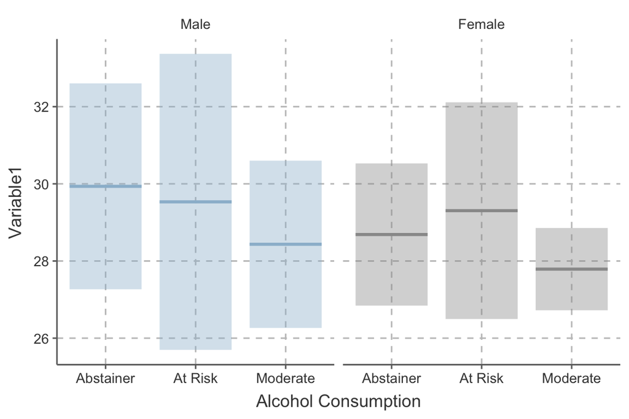

```r
visreg(m,
       xvar = "AUDITCat", by = "Sex",
       overlay = FALSE, partial = FALSE, band = TRUE, rug = FALSE, gg = TRUE) +
  ylab("Variable1") + xlab("Alcohol Consumption")
```

Alternatively, we can use the `emmip()` function to graph our result. We now separate our results by levels of alcohol consumption

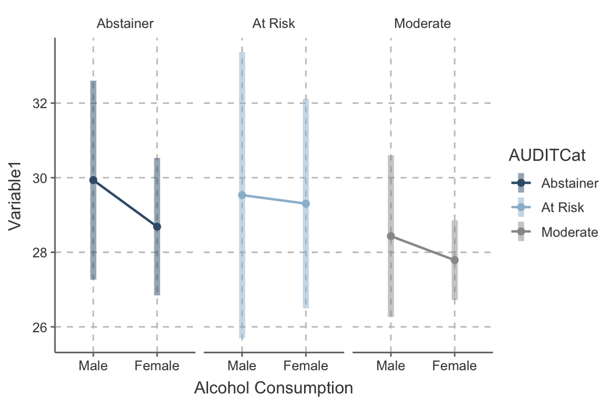

```r
emmip(em, ~ Sex | AUDITCat, CIs = TRUE) +
  ylab("Variable1") + xlab("Alcohol Consumption")
```